# Task 5

Gautam

7 October 2020

##Loading Required Libraries

```r
library(gsheet)#Access data from docs
library(dlookr)
library(dplyr)
```

```r
library(ggplot2)
library(forcats)
```

###Downloading Dataset

```r
superstore <- gsheet2tbl('https://docs.google.com/spreadsheets/d/1ELHYd5wKnLdJE3tuszI-Ced_hyye5CnOnArshR_UGPI/edit?usp=sharing')
str(superstore)
```

```
## tibble [9,994 x 13] (S3: spec_tbl_df/tbl_df/tbl/data.frame)
##  $ Ship Mode   : chr [1:9994] "Second Class" "Second Class" "Second Class" "Standard Class" ...
##  $ Segment     : chr [1:9994] "Consumer" "Consumer" "Corporate" "Consumer" ...
##  $ Country     : chr [1:9994] "United States" "United States" "United States" "United States" ...
##  $ City        : chr [1:9994] "Henderson" "Henderson" "Los Angeles" "Fort Lauderdale" ...
##  $ State       : chr [1:9994] "Kentucky" "Kentucky" "California" "Florida" ...
##  $ Postal Code : num [1:9994] 42420 42420 90036 33311 33311 ...
##  $ Region      : chr [1:9994] "South" "South" "West" "South" ...
##  $ Category    : chr [1:9994] "Furniture" "Furniture" "Office Supplies" "Furniture" ...
##  $ Sub-Category: chr [1:9994] "Bookcases" "Chairs" "Labels" "Tables" ...
##  $ Sales       : num [1:9994] 262 731.9 14.6 957.6 22.4 ...
##  $ Quantity    : num [1:9994] 2 3 2 5 2 7 4 6 3 5 ...
##  $ Discount    : num [1:9994] 0 0 0 0.45 0.2 0 0 0.2 0.2 0 ...
##  $ Profit      : num [1:9994] 41.91 219.58 6.87 -383.03 2.52 ...
##  - attr(*, "spec")=
##   .. cols(
##   ..   `Ship Mode` = col_character(),
##   ..   Segment = col_character(),
##   ..   Country = col_character(),
##   ..   City = col_character(),
##   ..   State = col_character(),
##   ..   `Postal Code` = col_double(),
##   ..   Region = col_character(),
##   ..   Category = col_character(),
##   ..   `Sub-Category` = col_character(),
##   ..   Sales = col_double(),
##   ..   Quantity = col_double(),
##   ..   Discount = col_double(),
##   ..   Profit = col_double()
##   .. )
```

#Explatory Data Analysis

###Data Description Data contains Sales records from a Super-Store located in USA Ship Mode- The mode in which the product was shipped. 4 Possible Modes “First Class” “Same Day” “Second Class” “Standard Class”

Segment- The Sale segment 3 Possible Segments “Consumer” “Corporate” “Home Office”

Country- Country in which the sale was made. (United States)

City- The city in which the sale was made .

State- State in which the sale was made.

Postal Code- Postal Code for the region of the sale.

Region - The Region in which the sale was made. 4 possible values “South” “West” “Central” “East” Category- The category of product which was purchased. 3 possible values “Furniture” “Office Supplies” “Technology” Sub Category- A more in-depth category of update 17 possible values

Sales- Amount of money transaction for the Sale

Quantity- Quantity of products involved in the sale

Discount- Discount applied on the sale

Profit- Profit made from the sale

###Describe the data

```r
describe(superstore,Discount,Quantity,Profit,Sales)
```

```
## # A tibble: 4 x 26
##   variable     n    na    mean      sd se_mean   IQR skewness kurtosis      p00
##   <chr>    <int> <int>   <dbl>   <dbl>   <dbl> <dbl>    <dbl>    <dbl>    <dbl>
## 1 Discount  9994     0   0.156   0.206 0.00207   0.2     1.68     2.41  0.
## 2 Quantity  9994     0   3.79    2.23  0.0223    3       1.28     1.99  1.00e+0
## 3 Profit    9994     0  28.7   234.    2.34     27.6     7.56   397.   -6.60e+3
## 4 Sales     9994     0 230.    623.    6.23    193.     13.0    305.    4.44e-1
## # ... with 16 more variables: p01 <dbl>, p05 <dbl>, p10 <dbl>, p20 <dbl>,
## #   p25 <dbl>, p30 <dbl>, p40 <dbl>, p50 <dbl>, p60 <dbl>, p70 <dbl>,
## #   p75 <dbl>, p80 <dbl>, p90 <dbl>, p95 <dbl>, p99 <dbl>, p100 <dbl>
```

###Overview of the data

```r
Overview<-superstore %>% summarise(Sale=sum(Sales),Profit=sum(Profit))
Overview
```

```
## # A tibble: 1 x 2
##       Sale  Profit
##      <dbl>   <dbl>
## 1 2297201. 286397.
```

#####We can see from this plot there is a very clear difference in amount of sales made State-wise

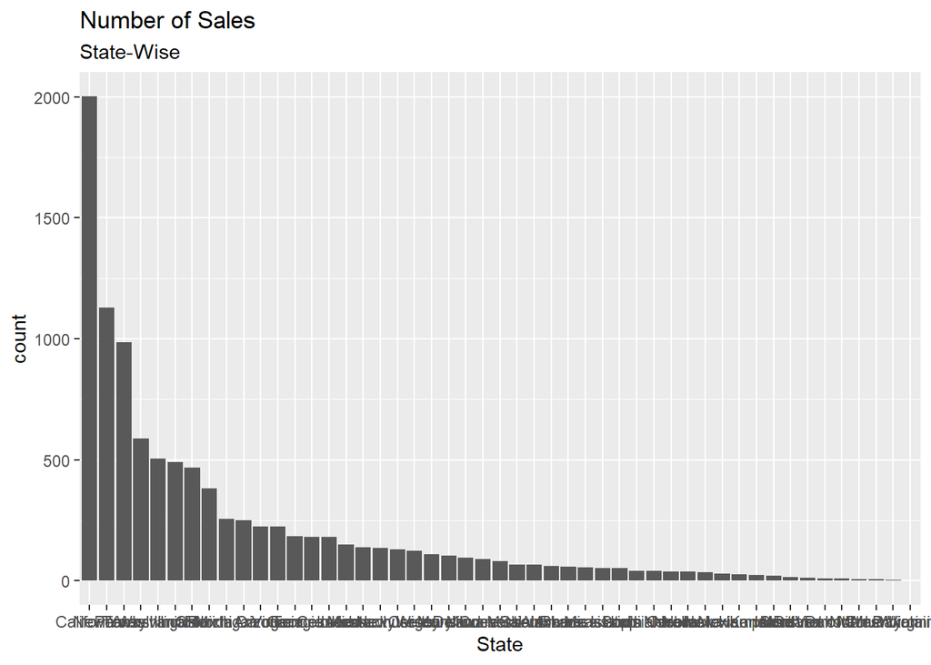

```r
ggplot(mutate(superstore,State=fct_infreq(State)))+geom_bar(aes(x=State))+ggtitle("Number of Sales","State-Wise")
```

####Number of Sales

```r
#Get the number of sales made in each state to find useful information
No_sales<-superstore %>% group_by(State) %>% summarise(N=n(),profit=mean(Profit)) %>% arrange(desc(N)) %>% head()
No_sales
```

```
## # A tibble: 6 x 3
##   State            N profit
##   <chr>        <int>  <dbl>
## 1 California    2001   38.2
## 2 New York      1128   65.6
## 3 Texas          985  -26.1
## 4 Pennsylvania   587  -26.5
## 5 Washington     506   66.0
## 6 Illinois       492  -25.6
```

```r
#Total Sales made:
nrow(superstore)
```

```
## [1] 9994
```

###Breakdown of Number of Sales

```r
#State-Wise sale % contribution
superstore %>% group_by(State) %>% summarise(PerCent=n()*100/nrow(superstore)) %>% arrange(desc(PerCent))
```

```
## # A tibble: 49 x 2
##    State          PerCent
##    <chr>            <dbl>
##  1 California       20.0
##  2 New York         11.3
##  3 Texas             9.86
##  4 Pennsylvania      5.87
##  5 Washington        5.06
##  6 Illinois          4.92
##  7 Ohio              4.69
##  8 Florida           3.83
##  9 Michigan          2.55
## 10 North Carolina    2.49
## # ... with 39 more rows
```

```r
#City-Wise sale %contribution
superstore %>% group_by(City) %>% summarise(PerCent=n()*100/nrow(superstore)) %>% arrange(desc(PerCent))
```

```
## # A tibble: 531 x 2
##    City          PerCent
##    <chr>           <dbl>
##  1 New York City    9.16
##  2 Los Angeles      7.47
##  3 Philadelphia     5.37
##  4 San Francisco    5.10
##  5 Seattle          4.28
##  6 Houston          3.77
##  7 Chicago          3.14
##  8 Columbus         2.22
##  9 San Diego        1.70
## 10 Springfield      1.63
## # ... with 521 more rows
```

###Focus on California

```r
# % of sales made in California
No_sales$N[1]*100/nrow(superstore)
```

```
## [1] 20.02201
```

```r
#what category of sales are being made in California?
California<-superstore %>% filter(State=="California")

#It seems as though our main category of sales in California is Office Supplies
California %>% group_by(Category) %>% summarise(N=n())
```

```
## # A tibble: 3 x 2
##   Category            N
##   <chr>           <int>
## 1 Furniture         444
## 2 Office Supplies  1198
## 3 Technology        359
```

```r
#Find the profit and sales
California %>% summarise(p=sum(Profit),s=sum(Sales))
```

```
## # A tibble: 1 x 2
##        p       s
##    <dbl>   <dbl>
## 1 76381. 457688.
```

###Profit Breakdown

```r
#Find the states that are most profitable
superstore %>% group_by(State) %>% summarise(Total_Profit=sum(Profit),SD=sd(Profit)) %>% arrange(desc(Total_Profit))
```

```
## # A tibble: 49 x 3
##    State      Total_Profit    SD
##    <chr>             <dbl> <dbl>
##  1 California       76381.  97.7
##  2 New York         74039. 233.
##  3 Washington       33403. 325.
##  4 Michigan         24463. 375.
##  5 Virginia         18598. 235.
##  6 Indiana          18383. 694.
##  7 Georgia          16250. 283.
##  8 Kentucky         11200. 171.
##  9 Minnesota        10823. 506.
## 10 Delaware          9977. 519.
## # ... with 39 more rows
```

```r
#Discounts are an important factor in sales and profit
dis<-superstore %>% group_by(State) %>% summarise(Avg=mean(Discount)) %>% arrange(desc(Avg)) %>% head()
dis
```

```
## # A tibble: 6 x 2
##   State          Avg
##   <chr>        <dbl>
## 1 Illinois     0.390
## 2 Texas        0.370
## 3 Pennsylvania 0.329
## 4 Ohio         0.325
## 5 Colorado     0.316
## 6 Arizona      0.304
```

```r
superstore %>% group_by(State) %>% filter(State%in%dis$State) %>% summarise(Total=sum(Sales))
```

```
## # A tibble: 6 x 2
##   State          Total
##   <chr>          <dbl>
## 1 Arizona       35282.
## 2 Colorado      32108.
## 3 Illinois      80166.
## 4 Ohio          78258.
## 5 Pennsylvania 116512.
## 6 Texas        170188.
```

```r
sales<-superstore %>% group_by(State) %>% summarise(Total=sum(Sales)) %>% arrange(desc(Total))
max(sales$Total)
```

```
## [1] 457687.6
```

```r
#Find the states which bring the most amount of money in sales
valued_states<-sales$State[1:20]
```

###Category Breakdown

```r
#Which Category of Sales brings the maximum sales and profits? -Technology
superstore %>% group_by(Category) %>% summarise(Total_Sale=sum(Sales),Total_Profit=sum(Profit))
```

```
## # A tibble: 3 x 3
##   Category        Total_Sale Total_Profit
##   <chr>                <dbl>        <dbl>
## 1 Furniture          742000.       18451.
## 2 Office Supplies    719047.      122491.
## 3 Technology         836154.      145455.
```

```r
superstore %>% group_by(State) %>% filter(Category=="Technology") %>% summarise(N=n()) %>% arrange(desc(N))
```

```
## # A tibble: 46 x 2
##    State              N
##    <chr>          <int>
##  1 California       359
##  2 New York         208
##  3 Texas            179
##  4 Pennsylvania     119
##  5 Ohio             102
##  6 Washington       100
##  7 Illinois          84
##  8 Florida           69
##  9 North Carolina    51
## 10 Arizona           48
## # ... with 36 more rows
```

```r
#We see California pops up again as the biggest customer
```

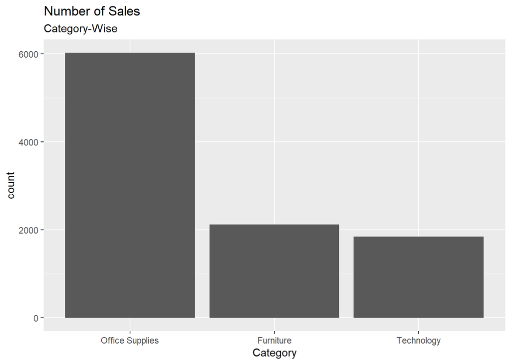

```r
#What category has the most sales ?
ggplot(mutate(superstore,Category=fct_infreq(Category)))+geom_bar(aes(x=Category))+ggtitle("Number of Sales","Category-Wise")
```

```r
superstore %>% group_by(Category) %>% summarise(n())
```

```
## # A tibble: 3 x 2
##   Category        `n()`
##   <chr>           <int>
## 1 Furniture        2121
## 2 Office Supplies  6026
## 3 Technology       1847
```

#####In more Detail

```r
Sold_Category<-superstore %>% group_by(State,Category) %>% summarise(N=n()) %>% arrange(desc(N))
Sold_Category
```

```
## # A tibble: 142 x 3
## # Groups:   State [49]
##    State        Category            N
##    <chr>        <chr>           <int>
##  1 California   Office Supplies  1198
##  2 New York     Office Supplies   684
##  3 Texas        Office Supplies   604
##  4 California   Furniture         444
##  5 California   Technology        359
##  6 Pennsylvania Office Supplies   343
##  7 Washington   Office Supplies   292
##  8 Illinois     Office Supplies   285
##  9 Ohio         Office Supplies   274
## 10 New York     Furniture         236
## # ... with 132 more rows
```

```r
#Check what % of sales were discounted for big sale spots (States)
superstore %>% group_by(State) %>% filter(State%in%valued_states) %>%
  summarise(T_S=sum(Sales),T_D=sum(Discount),T_P=sum(Profit),Percent=T_D*100/T_S) %>% arrange(desc(T_P))
```

```
## # A tibble: 20 x 5
##    State              T_S   T_D     T_P Percent
##    <chr>            <dbl> <dbl>   <dbl>   <dbl>
##  1 California     457688. 146.   76381. 0.0318
##  2 New York       310876.  62.4  74039. 0.0201
##  3 Washington     138641.  32.4  33403. 0.0234
##  4 Michigan        76270.   1.8  24463. 0.00236
##  5 Virginia        70637.   0    18598. 0
##  6 Indiana         53555.   0    18383. 0
##  7 Georgia         49096.   0    16250. 0
##  8 Kentucky        36592.   0    11200. 0
##  9 Minnesota       29863.   0    10823. 0
## 10 New Jersey      35764.   0.6   9773. 0.00168
## 11 Wisconsin       32115.   0     8402. 0
## 12 Florida         89474. 115.   -3399. 0.128
## 13 Arizona         35282.  68    -3428. 0.193
## 14 Tennessee       30662.  53.3  -5342. 0.174
## 15 Colorado        32108.  57.6  -6528. 0.179
## 16 North Carolina  55603.  70.6  -7491. 0.127
## 17 Illinois        80166. 192.  -12608. 0.239
## 18 Pennsylvania   116512. 193.  -15560. 0.166
## 19 Ohio            78258. 152.  -16971. 0.195
## 20 Texas          170188. 365.  -25729. 0.214
```

#California and New York are the two most important locations for this store, it would be advised to focus their attention and expand in these two location as these have the most promise.